# xv20230817_mutations_analysis

x.vergara

2023-08-22

I will explore the data that I received from Mathijs and proccess it as we did previously for BRCA2mut tumors

```r
knitr::opts_chunk$set(root.dir = '/home/x.vergara/XV_P3_ChromDSBScreen/xv_CRISPR_screen_figures/rmarkdown/xv20210920_paper_scripts/short_version/knit_html/')

StartTime <-Sys.time()
library(knitr)

# 8-digit Date tag:
Date <- substr(gsub("-","",Sys.time()),1,8)

#Change in.dir accordingly
in.dir <- "/home/x.vergara/XV_P3_ChromDSBScreen/xv_CRISPR_screen_figures/"

#Check if output contain datetag
saveRDS_proof <- function(object, file) {
  if (grepl(Date, file) == T) {
    saveRDS(object, file)
  }
  else {
    print("Incorrect datetag!")
  }
}

#Read rds check through different versions
readRDS_proof <- function(path, pat) {
  full.path <- paste0(in.dir, path)
  document_path <- rstudioapi::getSourceEditorContext()$path %>% str_split(pattern = "/") %>% unlist()
  document_name <- document_path[length(document_path)]
  sys_time <- Sys.time()

  if(file.exists(full.path) == T){
    if(paste0(in.dir,path) != getwd()){
      setwd(paste0(in.dir, path))
  }
    file.list <- list.files(pattern = pat)
    correct_file <- str_sort(file.list, decreasing = T)[1]
    print(correct_file)
    write(c(document_name,as.character(sys_time) ,"Input", correct_file), file = paste0(in.dir,"log"), ncolumns = 4, sep = "\t", append = T)
    readRDS(correct_file)

  }
  else{
  setwd(path)
  file.list <- list.files(pattern = pat)
  correct_file <- str_sort(file.list, decreasing = T)[1]
  print(correct_file)
  write(c(document_name, as.character(sys_time),"Input", correct_file),file = paste0(in.dir,"log"), ncolumns = 4, sep = "\t", append = T)
  readRDS(correct_file)
  }
}
```

## Libraries:

```r
library(readxl)
library(tidyverse)
library(GenomicRanges)
library(rtracklayer)
library(ggbeeswarm)
```

#Are there samples represented twice?

```r
#Indel data
repeated_samples <- SV_all_tumors %>%
  select(sample) %>%
  distinct() %>%
  dplyr::group_by(sample) %>%
  dplyr::summarise(count = n())

#filter repeated
repeated_samples %>% filter(count > 1)
```

```
## # A tibble: 0 × 2
## # … with 2 variables: sample <chr>, count <int>
```

```r
print("There are not repeated tumors assigned twice")
```

```
## [1] "There are not repeated tumors assigned twice"
```

#Summary of imported indel files

```r
#Summary text for nuber of indels
print(paste("This script imported a total of",
            nrow(SV_all_tumors),
            "indels from",
            length(unique(SV_all_tumors$driver_mut)),
            "different genetic backgrounds and",
            length(unique(SV_all_tumors$sample)),
            "human tumor genomes."))
```

```
## [1] "This script imported a total of 48047 indels from 15 different genetic backgrounds and 305 human tumor genomes."
```

#CONCLUSION: Indel data can also be imported and merged with BRCA2 and CTR datasets

#Plot number of indels per human genome

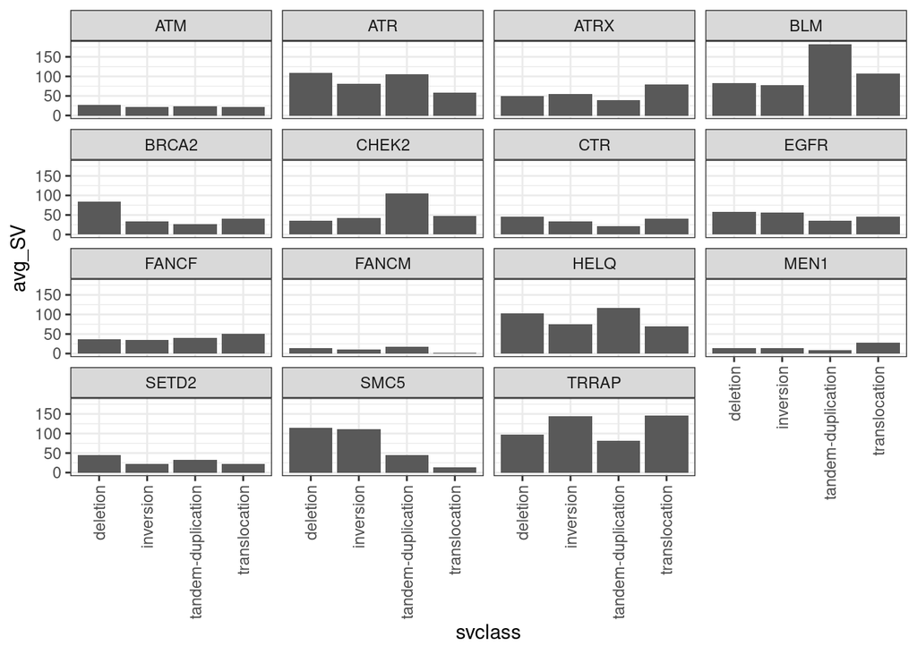

```r
#Plot indel summary per human genome
SV_relative_to_human_genome <- SV_all_tumors %>%
  dplyr::group_by(sample, driver_mut, svclass) %>%
  dplyr::summarise(counts = n()) %>%
  ungroup() %>%
  dplyr::group_by(driver_mut, svclass) %>%
  dplyr::summarise(avg_SV = mean(counts))
#Plot total SV summary of all tumors
ggplot(SV_relative_to_human_genome) +
  geom_col(aes(svclass,avg_SV)) +
  facet_wrap(~ driver_mut) +
  theme_bw() +
  theme(axis.text.x = element_text(angle = 90,
                                   hjust = 1,
                                   vjust = 0.5))
```

#Import qualitative data

```r
pcaw_TCGA_donor <- read_delim("/DATA/projects/DSBrepair/data/xv20230818_PCAWG_data_revision/DATA_PCAWG/INFO/pcawg_TCGA_to_donorID.txt")
selection <- read_delim("/DATA/projects/DSBrepair/data/xv20230818_PCAWG_data_revision/DATA_PCAWG/INFO/selection.txt")
#Combine them
tumor_info <- left_join(pcaw_TCGA_donor,selection, c("TCGA_ID" = "sample_id")) %>% separate(ttype, into = c("tissue","type"), remove = F)
```

#CONCLUSION: Tumor info is combined in a single data table

#Add tumor data to indel and summaryse number per driver, tumor type and tissue

```r
#Indel data
SV_tumors_info <- left_join(SV_all_tumors, tumor_info, c("sample"="TCGA_ID"))

#Summary table
summary_table <- SV_tumors_info %>%
  select(driver_mut, type, tissue, sample) %>%
  distinct()

#Number of samples per drivers
drivers_summary <- summary_table %>%
  dplyr::group_by(driver_mut) %>%
  dplyr::summarise(driver_n = n()) %>%
  arrange(desc(driver_n))

#Pull vector type
driver_desc_order <- drivers_summary %>% pull(driver_mut)

#Number of samples per tumor type
type_summary <- summary_table %>%
  dplyr::group_by(type,tissue) %>%
  dplyr::summarise(type_n = n()) %>%
  arrange(desc(type_n))
#Number of samples per tissue
tissue_summary <- summary_table %>%
  dplyr::group_by(tissue) %>%
  dplyr::summarise(tissue_n = n()) %>%
  arrange(desc(tissue_n))

#Pull vector tissue
tissue_desc_order <- tissue_summary %>% pull(tissue)

#Summary table of total
summary_table_indels <- summary_table %>%
  left_join(drivers_summary) %>% #First drivers
  left_join(type_summary) %>% #Then type
  left_join(tissue_summary) #Third per tissue
```

#Plot tissue per driver mutation

```r
#Prepare data frame for this classification
classifier_table <- summary_table %>%
  dplyr::group_by(driver_mut, tissue, type) %>%
  dplyr::summarise(classifier_n = n())
```

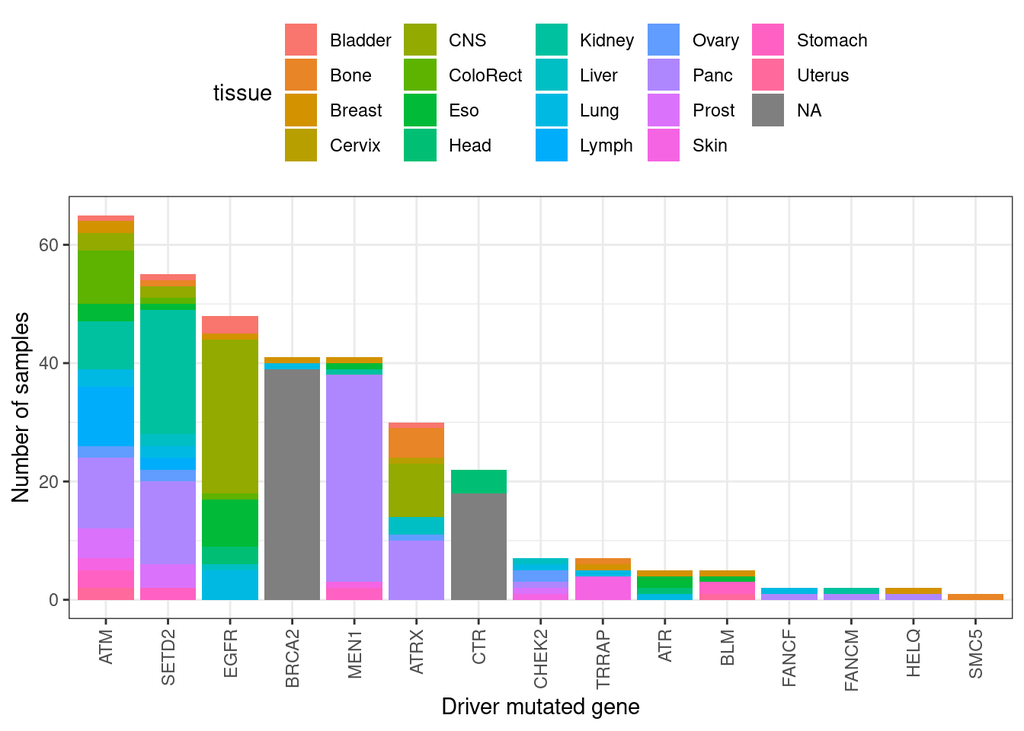

```r
#Plot samples per tumor
ggplot(classifier_table) +
  geom_col(aes(fct_relevel(driver_mut, driver_desc_order),
               classifier_n,
               fill = tissue)) +
  theme_bw() +
  theme(axis.text.x = element_text(angle = 90,
                                   hjust = 1,
                                   vjust = 0.5),
        legend.position = "top") +
  ylab("Number of samples") +
  xlab("Driver mutated gene")
```

#Filter SV data used in the screen and plot total number

```r
#Filter deletions with MH
MH_deletion_data <- SV_tumors_info %>%
    filter(svclass == "deletion" &
             length(`micro-homology`) > 1 &
             `micro-homology` != "." &
             `non-template` == "." &
             `Brass Notation` != "_")
```

#Are there samples with no deletion?

```r
#Calculate number of total deletions per tumors
MH_deletion_table <- MH_deletion_data %>%
  dplyr::group_by(sample) %>%
  dplyr::summarise(del_SV_count = n()) %>%
  right_join(summary_table_indels)
```

#Calculate the number of indels per class and sample

```r
#How many empty values are here?
print(paste("There are a total of",
            sum(is.na(MH_deletion_table$del_SV_count)),
            "samples that have no micro-homology SV"))
```

```
## [1] "There are a total of 31 samples that have no micro-homology SV"
```

```r
#Transform NA into 0
MH_deletion_table[is.na(MH_deletion_table$del_SV_count),]$del_SV_count <- 0

#NOTE: I will not add a pseudocount here, because in principal I don't need a logaritmic metric (THIS MIGHT CHANGE!)
```

#First QC: How much deletion classes change per tissue?

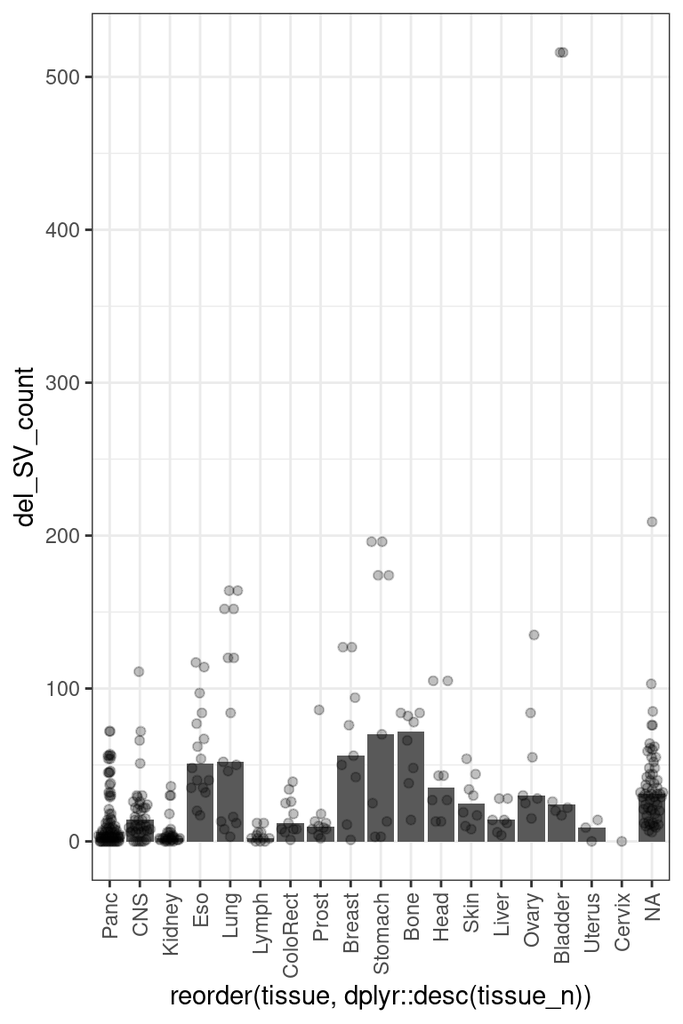

```r
#
ggplot(MH_deletion_table,aes(reorder(tissue, dplyr::desc(tissue_n)),del_SV_count)) +
  stat_summary(geom = "bar",fun = "median") +
  geom_quasirandom(alpha = 0.25) +
  theme_bw() +
  theme(axis.text.x = element_text(angle = 90,
                                   hjust = 1,
                                   vjust = 0.5))
```

#CONCLUSION: There are very clear differences in the amount of SV per tissue, in some of them there are not that many of them